# 100 runs on Simulated DSEM Data

This document presents an extended analysis of parameter recovery in six Dynamic Structural Equation Models (DSEM) as detailed in Hamaker et al.’s 2023 book chapter. For a comprehensive understanding, please refer to the preceding .html document, which introduces the observation that parameter recovery accuracy varies with different seed settings. This phenomenon has been similarly noted by Baral & Curran (2023) in their publication “Dynamic Structural Equation Models: Promising Yet Concerning,” accessible here: [AJUR Online](https://ajuronline.org/uploads/Volume_20_3/AJUR_Vol_20_Issue_3_Dec_2023_p69.pdf). In this analysis, I have executed 100 distinct seed iterations across all six models, utilizing both Stan and Mplus for simulation. Presented herein are the density distributions derived from the outputs of these 100 simulations. It is important to note that this script is designed for data analysis and does not sample; it solely processes the output data from these simulations.

## 0.1 Packages and Parameters

First, load the libraries and functions that will be needed later on. Additionally, read in ground truth parameters values here.

```r
library(tidyverse)
library(MplusAutomation)
library(cmdstanr)
library(bayesplot)
library(RColorBrewer)
library(MASS)
library(igraph)
library(ggpubr)

source("source/loadFunction.R") #custom function to load functions from source folder
LoadFunction(file="source/results.r", est_100_comb) # load the plot function
LoadFunction(file="source/extractData.r", extractData) # load the extract data function

varsNames = c("X", "Y", "phi_X", "phi_Y", "phi_XY", "beta_YX", "psi_X", "psi_Y")
'%out%' <- Negate('%in%')

# standard deviation for the mean + X stdDev data pre-processing.
stdIn = 3

# Ground Truth values for simulation
# Range of parameters taken from Hamaker et al., 2018
## https://doi.org/10.1080/00273171.2018.1446819
mu_phi_X = .2
mu_phi_Y = .25
mu_phi_XY = .05
mu_beta_YX = 0.3

mu_log_psi_X_2 = -1.6
mu_log_psi_Y_2 = -1.4

mu_X = 3.0
mu_Y = 1.0

# Ground Truth in vector gamma
gamma = c(mu_X, mu_Y, mu_phi_X, mu_phi_Y, mu_phi_XY, mu_beta_YX, mu_log_psi_X_2, mu_log_psi_Y_2)
```

# 1 Model 1

## 1.1 Extract Data & Convergence Stats

```r
modelNr = 1
modelName = "Hamaker 2018 model 1"
# Extract data function stored in source folder
extractData()
```

```
[1] "Removed 1 Stan estimates out of 100"
[1] "Stan had mean convergence time: 13 minutes (sd = 4.88), and median Rhat 1.018 (sd = 0.06)"
[1] "Removed 1 Mplus estimates out of 100"
[1] "Mplus had mean convergence time: 0 minutes (sd = 0), and mean Rhat 1.0002 (sd = 0)"
```

## 1.2 Results

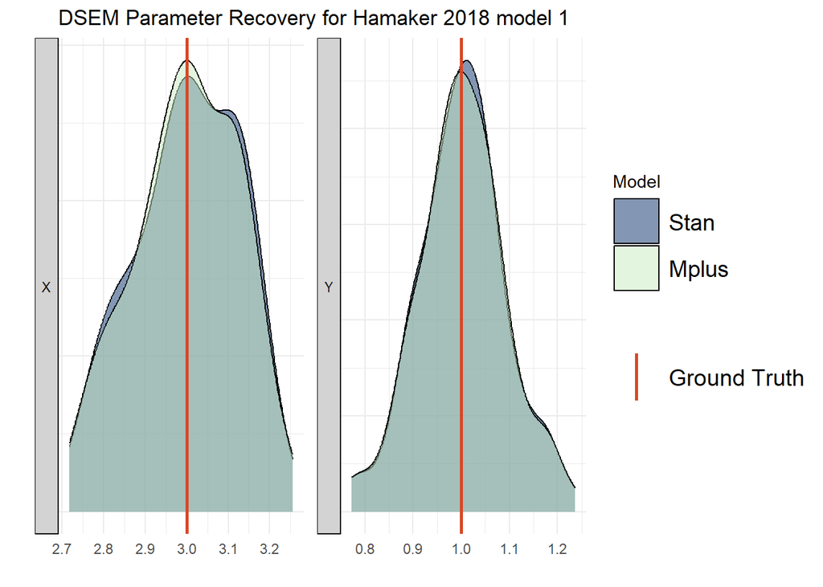

```r
# Plot function in source folder
est_100_comb(savePlots = FALSE)
```

# 2 Model 2

## 2.1 Extract Data & Convergence Stats

```r
modelNr = 2
modelName = "Hamaker 2018 model 2"
# Extract data function stored in source folder
extractData()
```

```
[1] "Removed 3 Stan estimates out of 100"
[1] "Stan had mean convergence time: 14.63 minutes (sd = 2.4), and median Rhat 1.002 (sd = 0)"
[1] "Removed 2 Mplus estimates out of 100"
[1] "Mplus had mean convergence time: 1.92 minutes (sd = 0.307), and mean Rhat 1.0002 (sd = 0)"
```

## 2.2 Results

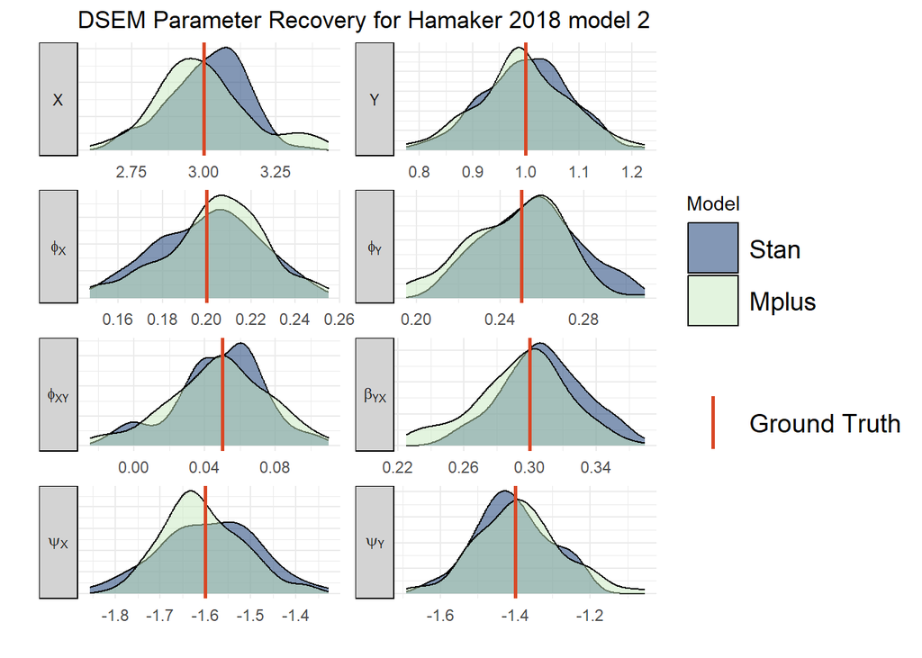

```r
# Plot function in source folder
est_100_comb(savePlots = FALSE)
```

# 3 Model 3

## 3.1 Extract Data & Convergence Stats

```r
modelNr = 3
modelName = "Hamaker 2018 model 3"
# Extract data function stored in source folder
extractData()
```

```
[1] "Removed 0 Stan estimates out of 100"
[1] "Stan had mean convergence time: 10.66 minutes (sd = 2.49), and median Rhat 1.002 (sd = 0)"
[1] "Removed 2 Mplus estimates out of 100"
[1] "Mplus had mean convergence time: 2.04 minutes (sd = 0.197), and mean Rhat 1.0002 (sd = 0)"
```

## 3.2 Results

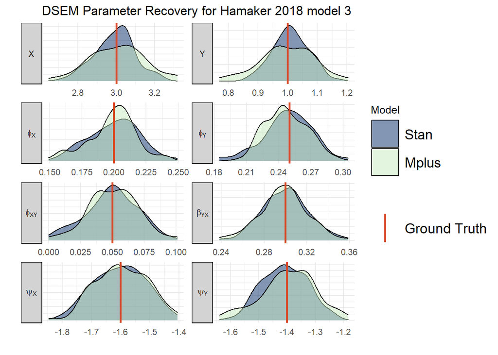

```r
# Plot function in source folder
est_100_comb(savePlots = FALSE)
```

# 4 Model 4

## 4.1 Extract Data & Convergence Stats

```r
modelNr = 4
modelName = "Hamaker 2018 model 4"
# Extract data function stored in source folder
extractData()
```

```
[1] "Removed 1 Stan estimates out of 100"
[1] "Stan had mean convergence time: 14.73 minutes (sd = 2.21), and median Rhat 1.024 (sd = 0.01)"
[1] "Removed 2 Mplus estimates out of 100"
[1] "Mplus had mean convergence time: 2.48 minutes (sd = 0.99), and mean Rhat 1.001 (sd = 0)"
```

## 4.2 Results

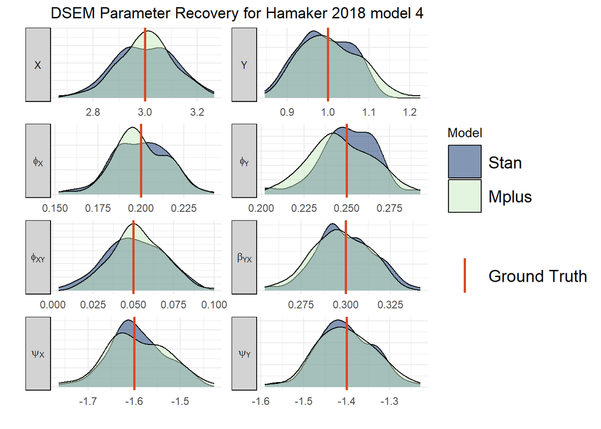

```r
# Plot function in source folder
est_100_comb(savePlots = FALSE)
```

# 5 Model 5

## 5.1 Extract Data & Convergence Stats

```r
modelNr = 5
modelName = "Hamaker 2018 model 5"
# Extract data function stored in source folder
extractData()
```

```
[1] "Removed 1 Stan estimates out of 100"
[1] "Stan had mean convergence time: 17.88 minutes (sd = 14.14), and median Rhat 1.003 (sd = 0.28)"
[1] "Removed 2 Mplus estimates out of 100"
[1] "Mplus had mean convergence time: 2.07070707070707 minutes (sd = 0.258), and mean Rhat 1.0002 (sd = 0)"
```

## 5.2 Results

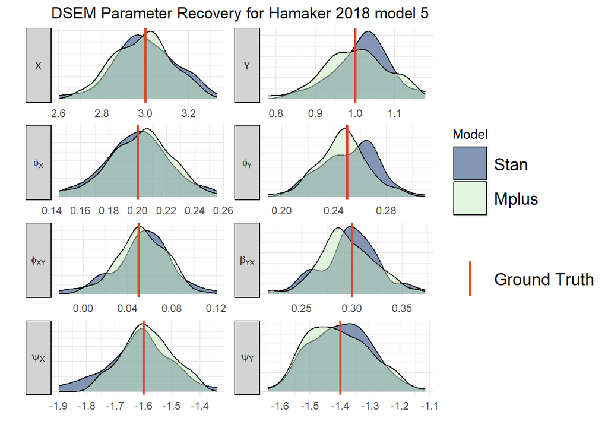

```r
# Plot function in source folder
est_100_comb(savePlots = FALSE)
```